# **Milestone 1**

## **Data Description**

There are a total of 24,958 train and 2,600 test images (colored) that we have taken from microscopic images. These images are of the following categories:

**Parasitized:** The parasitized cells contain the Plasmodium parasite which causes malaria  
**Uninfected:** The uninfected cells are free of the Plasmodium parasites

## **Important Notes**

- This notebook can be considered a guide to refer to while solving the problem. The evaluation will be as per the Rubric shared for each Milestone. Unlike previous courses, it does not follow the pattern of the graded questions in different sections. This notebook would give you a direction on what steps need to be taken in order to get a viable solution to the problem. Please note that this is just one way of doing this. There can be other 'creative' ways to solve the problem and we urge you to feel free and explore them as an 'optional' exercise.
- In the notebook, there are markdowns cells called - Observations and Insights. It is a good practice to provide observations and extract insights from the outputs.
- The naming convention for different variables can vary. Please consider the code provided in this notebook as a sample code.
- All the outputs in the notebook are just for reference and can be different if you follow a different approach.
- There are sections called **Think About It** in the notebook that will help you get a better understanding of the reasoning behind a particular technique/step. Interested learners can take alternative approaches if they want to explore different techniques.

### **Mounting the Drive**

```python
# Mounting the drive
from google.colab import drive
drive.mount('/content/drive')
```

### **Loading libraries**

```python
# Importing libraries required to load the data
import zipfile

import os

from PIL import Image

import numpy as np

import pandas as pd

import matplotlib.pyplot as plt

import seaborn as sns

from sklearn.model_selection import train_test_split

from sklearn.preprocessing import MinMaxScaler

# To ignore warnings
import warnings

warnings.filterwarnings('ignore')

# Remove the limit from the number of displayed columns and rows. It helps to see the entire dataframe while printing it
pd.set_option("display.max_columns", None)

pd.set_option("display.max_rows", 200)
```

### **Let us load the data**

**Note:**

- You must download the dataset from the link provided on Olympus and upload the same on your Google drive before executing the code in the next cell.
- In case of any error, please make sure that the path of the file is correct as the path may be different for you.

```python
# Storing the path of the data file from the Google drive
path = '/content/drive/MyDrive/Colab Notebooks/cell_images.zip'

# The data is provided as a zip file so we need to extract the files from the zip file
with zipfile.ZipFile(path, 'r') as zip_ref:

    zip_ref.extractall()
```

The extracted folder has different folders for train and test data which further contains the different sizes of images for parasitized and uninfected cells within the respective folder name.

The size of all images must be the same and should be converted to 4D arrays so that they can be used as an input for the convolutional neural network. Also, we need to create the labels for both types of images to be able to train and test the model.

Let's do the same for the training data first and then we will use the same code for the test data as well.

```python
# Storing the path of the extracted "train" folder
train_dir = '/content/cell_images/train'

# Size of image so that each image has the same size
SIZE = 64

# Empty list to store the training images after they are converted to NumPy arrays
train_images = []

# Empty list to store the training labels (0 - uninfected, 1 - parasitized)
train_labels = []
```

```python
# We will run the same code for "parasitized" as well as "uninfected" folders within the "train" folder
for folder_name in ['/parasitized/', '/uninfected/']:

    # Path of the folder
    images_path = os.listdir(train_dir + folder_name)

    for i, image_name in enumerate(images_path):

        try:

            # Opening each image using the path of that image
            image = Image.open(train_dir + folder_name + image_name)

            # Resizing each image to (64, 64)
            image = image.resize((SIZE, SIZE))

            # Converting images to arrays and appending that array to the empty list defined above
            train_images.append(np.array(image))

            # Creating labels for parasitized and uninfected images
            if folder_name == '/parasitized/':

                train_labels.append(1)

            else:

                train_labels.append(0)

        except Exception:

            pass

# Converting lists to arrays
train_images = np.array(train_images)

train_labels = np.array(train_labels)
```

```python
# Storing the path of the extracted "test" folder
test_dir = '/content/cell_images/test'

# Size of image so that each image has the same size (it must be same as the train image size)
SIZE = 64

# Empty list to store the testing images after they are converted to NumPy arrays
test_images = []

# Empty list to store the testing labels (0 - uninfected, 1 - parasitized)
test_labels = []
```

```python
# We will run the same code for "parasitized" as well as "uninfected" folders within the "test" folder
for folder_name in ['/parasitized/', '/uninfected/']:

    # Path of the folder
    images_path = os.listdir(test_dir + folder_name)

    for i, image_name in enumerate(images_path):

        try:
            # Opening each image using the path of that image
            image = Image.open(test_dir + folder_name + image_name)

            # Resizing each image to (64, 64)
            image = image.resize((SIZE, SIZE))

            # Converting images to arrays and appending that array to the empty list defined above
            test_images.append(np.array(image))

            # Creating labels for parasitized and uninfected images
            if folder_name == '/parasitized/':

                test_labels.append(1)

            else:

                test_labels.append(0)

        except Exception:

            pass

# Converting lists to arrays
test_images = np.array(test_images)

test_labels = np.array(test_labels)
```

### **Checking the shape of train and test images**

```python
# Shape of

print(train_images.shape)
print(test_images.shape)
```

```
(24958, 64, 64, 3)
(2600, 64, 64, 3)
```

### **Checking the shape of train and test labels**

```python
# Shape of labels

print(train_labels.shape)
print(test_labels.shape)
```

```
(24958,)
(2600,)
```

#### **Observations and insights: **_****

Here, we have all the images converted to 4D arrays.

The first dimension 24958 denotes the number of images in the training data, and each image is stacked on top of the other as a 3-dimensional Numpy Array.

The second dimension 64 is denoting the number of pixels along the x-axis, the third dimension 64 is denoting the number of pixels along the y-axis.

The fouth dimension 3 is the total number of channels in the images of RGB (Red, Gree, and Blue) as the data consists of color images.

### **Check the minimum and maximum range of pixel values for train and test images**

```python
# Try to use min and max function from numpy

print(train_images.min(), train_images.max())
print(test_images.min(), test_images.max())
```

```
0 255
0 255
```

#### **Observations and insights: **_****

The min for both train and test images are 0, and the max for boht train and test images are 255, meaning that in both train and test images, the pixel values are raning from 0-255.

### **Count the number of values in both uninfected and parasitized**

```python
# Try to use value_counts to count the values

# train_labels and test_labels is right now a numpy array
# so in order to use value_counts, we must convert it to pandas dataFrame

df_train_labels = pd.DataFrame(train_labels)
print(df_train_labels.value_counts())

# first row is 1 which is parasitized, and second row is 0 which is uninfected

df_test_labels = pd.DataFrame(test_labels)
print(df_test_labels.value_counts())

# first row is 0 which is uninfected, and second row is 1 which is parasitized
```

```
1    12582
0    12376
dtype: int64
0    1300
1    1300
dtype: int64
```

### **Normalize the images**

```python
# Try to normalize the train and test images by dividing it by 255 and convert them to float32 using astype function
print(train_images.dtype)
print(test_images.dtype)
train_images = (train_images/255).astype('float32')
test_images = (test_images/255).astype('float32')
print(train_images.dtype)
print(test_images.dtype)
```

```
uint8
uint8
float32
float32
```

#### **Observations and insights: **_****

By changing numpy array into data frame, we were able to use pandas value_counts.

Numbers of parasitized and uninfected cell pictures in train data are relatively close. Numbers of parasitized and uninfected cell pictures in test data are identical.

Since we have checked that the images are in range of 0-255 range, we divided the values by 255, which gives them a new range of 0-1.

### **Plot to check if the data is balanced**

[output not shown]

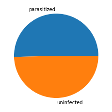

```python
# You are free to use bar plot or pie-plot or count plot, etc. to plot the labels of train and test data and check if they are balanced

train_counts = df_train.value_counts()
cell_labels = ["parasitized", "uninfected"]
plt.pie(train_counts, labels = cell_labels)
```

[output not shown]

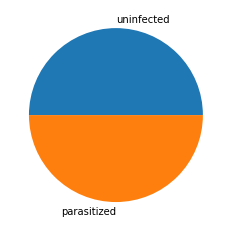

```python
test_counts = df_test.value_counts()
cell_labels = ["uninfected", "parasitized"]
plt.pie(test_counts, labels = cell_labels)
```

#### **Observations and insights: **_****

We can observe that the data is well balanced for both train and test data set.

### **Data Exploration**

Let's visualize the images from the train data

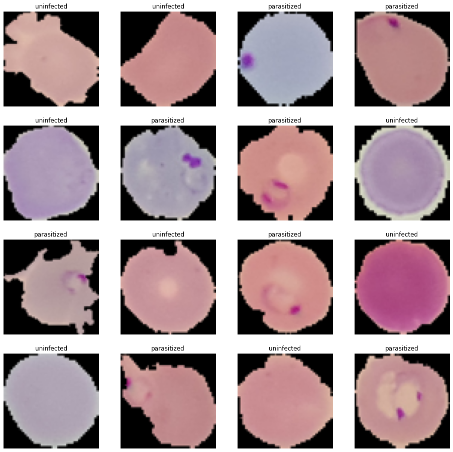

```python
# This code will help you in visualizing both the parasitized and uninfected images
np.random.seed(42)

plt.figure(1, figsize = (16 , 16))

for n in range(1, 17):

    plt.subplot(4, 4, n)

    index = int(np.random.randint(0, train_images.shape[0], 1))

    if train_labels[index] == 1:

        plt.title('parasitized')

    else:
        plt.title('uninfected')

    plt.imshow(train_images[index])

    plt.axis('off')
```

#### **Observations and insights: **_****

Images appear to be big on the screen, hard to compare each ones.

It appears to be that parasitized cells tend to have blue dots within cells, compared to uninfected cells.

### **Similarly visualize the images with subplot(6, 6) and figsize = (12, 12)**

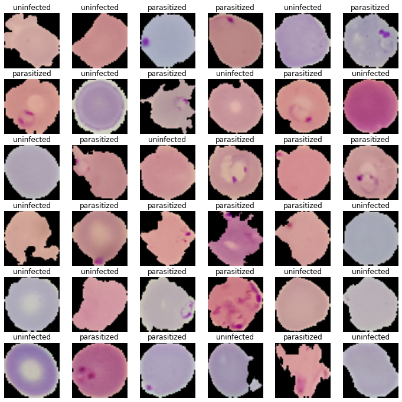

```python
# Hint: Have a keen look into the number of iterations that the for loop should iterate

np.random.seed(42)

plt.figure(1, figsize = (12 , 12))

for n in range(1, 37):

    plt.subplot(6, 6, n)

    index = int(np.random.randint(0, train_images.shape[0], 1))

    if train_labels[index] == 1:

        plt.title('parasitized')

    else:
        plt.title('uninfected')

    plt.imshow(train_images[index])

    plt.axis('off')
```

#### **Observations and insights:**

It appears to be easier to compare within pictures with this setup.

The parasitized cells have blue dots or ring shaped blue marks in them compared to uninfected ones.

The parasitized cells seem to have a tendency to have more irregular shape than uninfected cells, but need further evaluation.

The cells are generally placed in center of images, but there really isn't a "orientation" as it is typically round shaped and can be rotated.

### **Plotting the mean images for parasitized and uninfected**

```python
# Function to find the mean
def find_mean_img(full_mat, title):

    # Calculate the average
    mean_img = np.mean(full_mat, axis = 0)[0]

    # Reshape it back to a matrix
    plt.imshow(mean_img)

    plt.title(f'Average {title}')

    plt.axis('off')

    plt.show()

    return mean_img
```

**Mean image for parasitized**

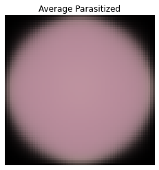

```python
# If the label = 1 then the image is parasitised and if the label = 0 then the image is uninfected
parasitized_data = []  # Create a list to store the parasitized data

for img, label in zip(train_images, train_labels):

        if label == 1:

              parasitized_data.append([img])

parasitized_mean = find_mean_img(np.array(parasitized_data), 'Parasitized')   # find the mean
```

**Mean image for uninfected**

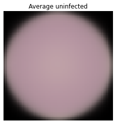

```python
# Similarly write the code to find the mean image of uninfected

# If the label = 1 then the image is parasitised and if the label = 0 then the image is uninfected
uninfected_data = []  # Create a list to store the parasitized data

for img, label in zip(train_images, train_labels):

        if label == 0:

              uninfected_data.append([img])

uninfected_mean = find_mean_img(np.array(uninfected_data), 'uninfected')   # find the mean
```

#### **Observations and insights: **_****

It appears to be that average parasitized cell mean image has more red and blue color in them compared to average uninfected cell mean image.

It does not appear that distinction between parasitized cell and uninfected cell can be easily made by looking at average mean image. The blue marks of parasitized cell would in anywhere within the cell and cell's shape distortion could also be anywhere within the image that averaging them makes that distinction very hard.

### **Converting RGB to HSV of Images using OpenCV**

### **Converting the train data**

```python
import cv2

gfx=[]   # to hold the HSV image array

for i in np.arange(0, 100, 1):

  a = cv2.cvtColor(train_images[i], cv2.COLOR_BGR2HSV)

  gfx.append(a)

gfx = np.array(gfx)
```

[output not shown]

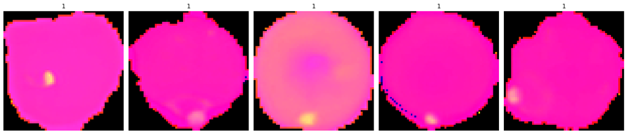

```python
viewimage = np.random.randint(1, 100, 5)

fig, ax = plt.subplots(1, 5, figsize = (18, 18))

for t, i in zip(range(5), viewimage):

  Title = train_labels[i]

  ax[t].set_title(Title)

  ax[t].imshow(gfx[i])

  ax[t].set_axis_off()

  fig.tight_layout()
```

### **Converting the test data**

```python
# Similarly you can visualize for the images in the test data

import cv2

gfx=[]   # to hold the HSV image array

for i in np.arange(0, 100, 1):

  b = cv2.cvtColor(test_images[i], cv2.COLOR_BGR2HSV)

  gfx.append(b)

gfx = np.array(gfx)
```

[output not shown]

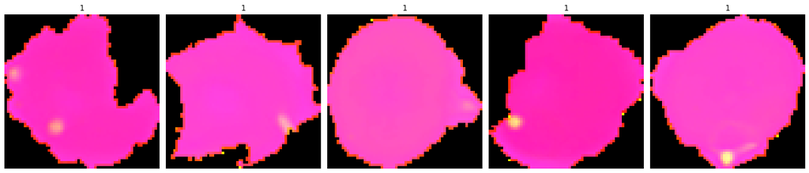

```python
viewimage = np.random.randint(1, 100, 5)

fig, ax = plt.subplots(1, 5, figsize = (18, 18))

for t, i in zip(range(5), viewimage):

  Title = test_labels[i]

  ax[t].set_title(Title)

  ax[t].imshow(gfx[i])

  ax[t].set_axis_off()

  fig.tight_layout()
```

#### **Observations and insights: **_****

The HSV images of train data is showing 5 different pics of cell that has yellow spot. They are typically round shaped.

### **Processing Images using Gaussian Blurring**

### **Gaussian Blurring on train data**

```python
gbx = []  # To hold the blurred images

for i in np.arange(0, 100, 1):

  b = cv2.GaussianBlur(train_images[i], (5, 5), 0)

  gbx.append(b)

gbx = np.array(gbx)
```

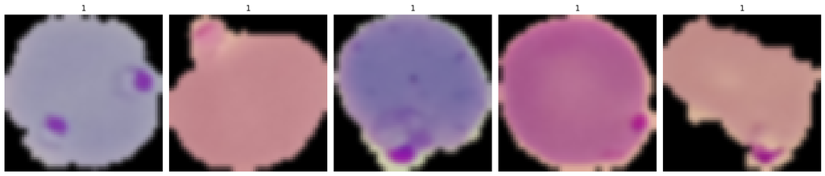

```python
viewimage = np.random.randint(1, 100, 5)

fig, ax = plt.subplots(1, 5, figsize = (18, 18))

for t, i in zip(range(5), viewimage):

  Title = train_labels[i]

  ax[t].set_title(Title)


  ax[t].imshow(gbx[i])

  ax[t].set_axis_off()

  fig.tight_layout()
```

### **Gaussian Blurring on test data**

```python
# Similarly you can apply Gaussian blurring for the images in the test data

gbx = []  # To hold the blurred images

for i in np.arange(0, 100, 1):

  b = cv2.GaussianBlur(test_images[i], (5, 5), 0)

  gbx.append(b)

gbx = np.array(gbx)
```

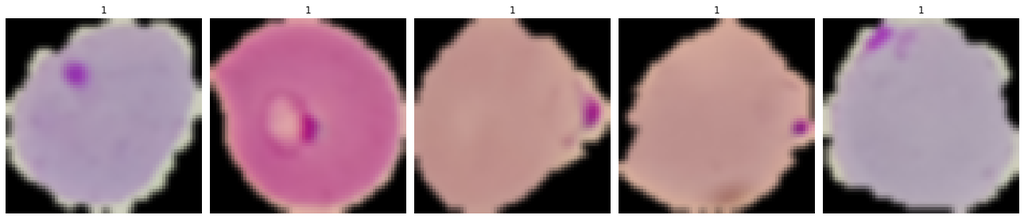

```python
viewimage = np.random.randint(1, 100, 5)

fig, ax = plt.subplots(1, 5, figsize = (18, 18))

for t, i in zip(range(5), viewimage):

  Title = train_labels[i]

  ax[t].set_title(Title)


  ax[t].imshow(gbx[i])

  ax[t].set_axis_off()

  fig.tight_layout()
```

#### **Observations and insights: **_****

**Think About It:** Would blurring help us for this problem statement in any way? What else can we try?

I don't think blurring would specifically help in this project, because the parasitized and uninfected cell has major differences that can be detected by existence of its blue marks within them, or more crippled shape, judging by the pictures with our eyes. Blurring would make it hard to detect both features that will be critical to making distinction between two groups of cells.